# 回帰分析

予測と発展的なモデル

村田 昇

# 講義の内容

- 第1回: 回帰モデルの考え方と推定
- 第2回: モデルの評価
- **第3回: モデルによる予測と発展的なモデル**

# 回帰分析の復習

## 線形回帰モデル

- **目的変数** を **説明変数** で説明する関係式を構成
  - 説明変数: $x_1,\dotsc,x_p$ (p次元)
  - 目的変数: $y$ (1次元)
- **回帰係数** $\beta_0,\beta_1,\dotsc,\beta_p$ を用いた一次式
  $$\begin{equation}
  y=\beta_0+\beta_1x_1+\dotsb+\beta_px_p
  \end{equation}$$
- **誤差項** を含む確率モデルで観測データを表現
  $$\begin{equation}
  y_i=\beta_0+\beta_1 x_{i1}+\cdots+\beta_px_{ip}+\epsilon_i
  \quad (i=1,\dotsc,n)
  \end{equation}$$

## 問題設定

- 確率モデル
  $$\begin{equation}
  \boldsymbol{y}
  =X\boldsymbol{\beta}+\boldsymbol{\epsilon},
  \quad\boldsymbol{\epsilon}\sim\text{確率分布}
  \end{equation}$$
- 式の評価 : **残差平方和** の最小化による推定
  $$\begin{equation}
  S(\boldsymbol{\beta})
  =(\boldsymbol{y}-X\boldsymbol{\beta})^{\mathsf{T}}
  (\boldsymbol{y}-X\boldsymbol{\beta})
  \end{equation}$$

## 解とその一意性

- 解の条件 : **正規方程式**
  $$\begin{equation}
  X^{\mathsf{T}}X\boldsymbol{\beta}
  =X^{\mathsf{T}}\boldsymbol{y}
  \end{equation}$$
- 解の一意性 : **Gram 行列** $X^{\mathsf{T}}X$ が正則
  $$\begin{equation}
  \hat{\boldsymbol{\beta}}
  =
  (X^{\mathsf{T}}X)^{-1}
  X^{\mathsf{T}}\boldsymbol{y}
  \end{equation}$$

# 解析の事例

## 気温に影響を与える要因の分析

- 気象庁より取得した東京の気候データ (再掲)
  - 気象庁 https://www.data.jma.go.jp/gmd/risk/obsdl/index.php

### データの概要

東京の8月の気候データ

| 日付 | 気温 | 降雨 | 日射 | 降雪 | 風向 | 風速 | 気圧 | 湿度 | 雲量 |
| --- | --- | --- | --- | --- | --- | --- | --- | --- | --- |
| 2025-08-01 | 26.4 | 6.0 | 9.16 | 0 | N | 3.3 | 999.0 | 83 | 10.0 |
| 2025-08-02 | 28.9 | 20.5 | 20.34 | 0 | SSE | 3.7 | 996.5 | 84 | 9.5 |
| 2025-08-03 | 30.4 | 0.0 | 21.10 | 0 | SSE | 2.6 | 1000.1 | 77 | 8.5 |
| 2025-08-04 | 31.3 | 0.0 | 26.14 | 0 | S | 4.3 | 1002.5 | 66 | 3.3 |
| 2025-08-05 | 32.1 | 0.0 | 25.58 | 0 | SSE | 3.2 | 1001.6 | 67 | 4.5 |
| 2025-08-06 | 32.3 | 0.0 | 23.20 | 0 | SSE | 2.4 | 999.8 | 68 | 7.5 |
| 2025-08-07 | 29.5 | 0.0 | 12.16 | 0 | N | 2.1 | 995.4 | 76 | 8.8 |
| 2025-08-08 | 28.6 | 3.0 | 17.46 | 0 | NW | 2.6 | 998.7 | 71 | 5.5 |
| 2025-08-09 | 28.4 | 0.0 | 18.21 | 0 | SSE | 2.7 | 1004.0 | 70 | 8.0 |
| 2025-08-10 | 26.3 | 25.5 | 4.32 | 0 | S | 4.1 | 1002.8 | 90 | 10.0 |
| 2025-08-11 | 27.1 | 11.5 | 7.97 | 0 | S | 5.6 | 1003.8 | 90 | 9.8 |
| 2025-08-12 | 28.2 | 1.0 | 6.88 | 0 | SSW | 4.4 | 1007.7 | 83 | 10.0 |
| 2025-08-13 | 27.9 | 0.0 | 17.21 | 0 | E | 2.4 | 1013.5 | 76 | 9.3 |
| 2025-08-14 | 27.8 | 0.0 | 20.39 | 0 | S | 2.6 | 1014.2 | 71 | 8.3 |
| 2025-08-15 | 28.7 | 0.0 | 24.42 | 0 | S | 2.9 | 1011.2 | 73 | 5.0 |
| 2025-08-16 | 28.8 | 1.0 | 19.08 | 0 | S | 3.1 | 1011.1 | 80 | 8.0 |
| 2025-08-17 | 29.8 | 0.0 | 22.79 | 0 | SSE | 3.2 | 1010.4 | 77 | 6.3 |
| 2025-08-18 | 31.0 | 0.0 | 22.43 | 0 | SSE | 2.5 | 1011.5 | 68 | 7.8 |
| 2025-08-19 | 29.9 | 0.0 | 22.92 | 0 | SE | 2.8 | 1009.6 | 76 | 2.0 |
| 2025-08-20 | 30.4 | 0.0 | 23.70 | 0 | SSE | 2.7 | 1007.5 | 72 | 3.5 |
| 2025-08-21 | 31.3 | 0.0 | 23.14 | 0 | SSE | 2.5 | 1007.4 | 63 | 6.5 |
| 2025-08-22 | 30.3 | 0.0 | 15.55 | 0 | SSE | 2.2 | 1007.9 | 71 | 10.0 |
| 2025-08-23 | 30.4 | 0.0 | 21.77 | 0 | SSE | 2.6 | 1007.7 | 73 | 7.3 |
| 2025-08-24 | 31.3 | 0.0 | 23.05 | 0 | NE | 2.3 | 1008.9 | 70 | 3.8 |
| 2025-08-25 | 30.6 | 0.0 | 17.21 | 0 | SSE | 2.7 | 1010.9 | 71 | 8.5 |
| 2025-08-26 | 30.1 | 0.0 | 20.41 | 0 | SSE | 3.7 | 1009.1 | 75 | 3.0 |
| 2025-08-27 | 30.7 | 0.0 | 23.07 | 0 | S | 3.6 | 1006.1 | 67 | 3.8 |
| 2025-08-28 | 28.9 | 0.0 | 15.70 | 0 | SSE | 3.0 | 1011.0 | 63 | 6.8 |
| 2025-08-29 | 28.7 | 0.0 | 18.41 | 0 | SSE | 2.4 | 1012.1 | 76 | 6.5 |
| 2025-08-30 | 31.6 | 0.0 | 23.26 | 0 | S | 2.5 | 1010.5 | 67 | 4.0 |
| 2025-08-31 | 30.9 | 0.0 | 21.83 | 0 | SE | 2.7 | 1010.3 | 73 | 1.3 |

### モデルの検討

- 気温を説明する5種類の線形回帰モデル
  - モデル1 : 気温 = F(気圧)
  - モデル2 : 気温 = F(日射)
  - モデル3 : 気温 = F(気圧, 日射)
  - モデル4 : 気温 = F(気圧, 日射, 湿度)
  - モデル5 : 気温 = F(気圧, 日射, 雲量)

### 関連するデータの散布図

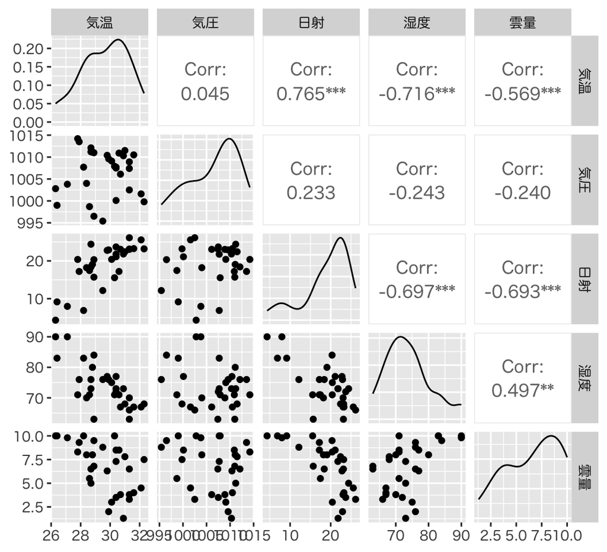

### 観測値とあてはめ値の比較

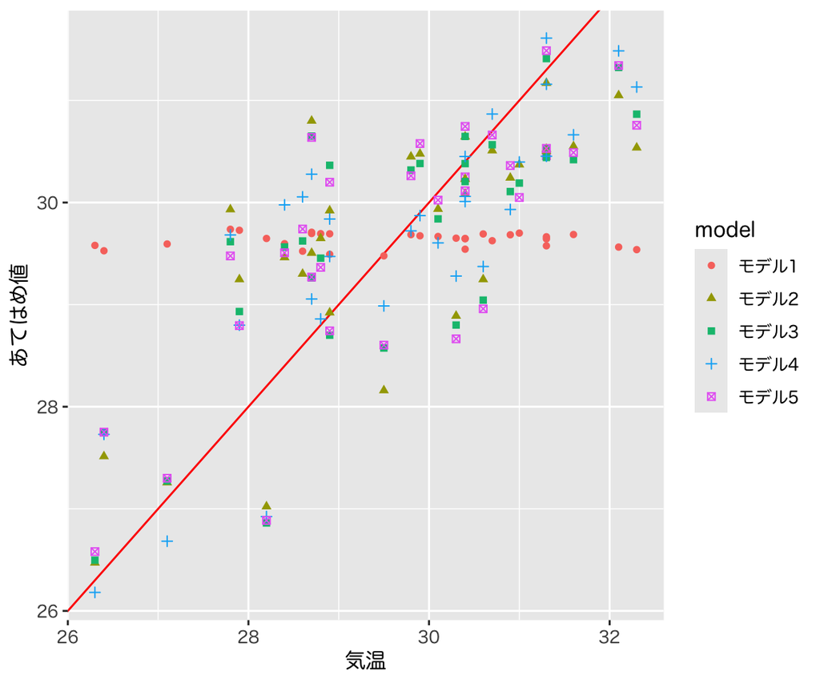

### 寄与率

- **決定係数** (R-squared)
  $$\begin{equation}
  R^2
  =
  1-\frac{\sum_{i=1}^n\hat{\epsilon}_i^2}{\sum_{i=1}^n(y_i-\bar{y})^2}
  \end{equation}$$
- **自由度調整済み決定係数** (adjusted R-squared)
  $$\begin{equation}
  \bar{R}^2
  =
  1-\frac{\frac{1}{n{-}p{-}1}\sum_{i=1}^n\hat{\epsilon}_i^2}
  {\frac{1}{n{-}1}\sum_{i=1}^n(y_i-\bar{y})^2}
  \end{equation}$$
  - 不偏分散で補正

### 決定係数($R^{2}$・Adjusted $R^{2}$)によるモデルの比較

| **変数** | モデル1 **係数(SE)**<sup>1</sup> | モデル2 **係数(SE)**<sup>1</sup> | モデル3 **係数(SE)**<sup>1</sup> | モデル4 **係数(SE)**<sup>1</sup> | モデル5 **係数(SE)**<sup>1</sup> |
| --- | --- | --- | --- | --- | --- |
| 気圧 | 0.01(0.057) |  | -0.04(0.037) | -0.05(0.035) | -0.05(0.038) |
| 日射 |  | 0.22(0.034)*** | 0.22(0.034)*** | 0.15(0.043)** | 0.21(0.047)*** |
| 湿度 |  |  |  | -0.09(0.035)* |  |
| 雲量 |  |  |  |  | -0.06(0.102) |
| R² | 0.002 | 0.585 | 0.604 | 0.678 | 0.609 |
| Adjusted R² | -0.032 | 0.571 | 0.576 | 0.642 | 0.566 |

<sup>1</sup> *p<0.05; **p<0.01; ***p<0.001  
Abbreviation: SE = 標準誤差

### $F$統計量による検定

- 説明変数のうち1つでも役に立つか否かを検定する
  - 帰無仮説 $H_{0}$ : $\beta_1=\dotsb=\beta_p=0$
  - 対立仮説 $H_{1}$ : $\exists j\;\beta_j\neq0$ (少なくとも1つは役に立つ)
- **$F$統計量** : 決定係数(または残差)を用いて計算
  $$\begin{equation}
  F
  =\frac{n{-}p{-}1}{p}\frac{R^2}{1-R^2}
  \end{equation}$$
- $p$値 : 自由度 $p,n{-}p{-}1$ の $F$分布で計算

### $F$統計量によるモデルの比較

| **変数** | モデル1 **係数(SE)**<sup>1</sup> | モデル2 **係数(SE)**<sup>1</sup> | モデル3 **係数(SE)**<sup>1</sup> | モデル4 **係数(SE)**<sup>1</sup> | モデル5 **係数(SE)**<sup>1</sup> |
| --- | --- | --- | --- | --- | --- |
| 気圧 | 0.01(0.057) |  | -0.04(0.037) | -0.05(0.035) | -0.05(0.038) |
| 日射 |  | 0.22(0.034)*** | 0.22(0.034)*** | 0.15(0.043)** | 0.21(0.047)*** |
| 湿度 |  |  |  | -0.09(0.035)* |  |
| 雲量 |  |  |  |  | -0.06(0.102) |
| R² | 0.002 | 0.585 | 0.604 | 0.678 | 0.609 |
| Statistic | 0.060 | 41.0 | 21.4 | 18.9 | 14.0 |
| p-value | 0.8 | <0.001 | <0.001 | <0.001 | <0.001 |

<sup>1</sup> *p<0.05; **p<0.01; ***p<0.001  
Abbreviation: SE = 標準誤差

### $t$統計量による検定

- 回帰係数 $\beta_j$ が回帰式に寄与するか否かを検定する
  - 帰無仮説 $H_{0}$ : $\beta_j=0$
  - 対立仮説 $H_{1}$ : $\beta_j\neq0$ ($\beta_j$ は役に立つ)
- **$t$統計量** : 各係数ごと，$\zeta^{2}$ は $(X^{\mathsf{T}} X)^{-1}$ の対角成分
  $$\begin{equation}
  t=\frac{\hat{\beta}_j}{\hat{\sigma}\zeta_{j}}
  \end{equation}$$
- $p$値 : 自由度 $n{-}p{-}1$ の $t$分布を用いて計算

### $t$統計量によるモデルの比較

| **変数** | モデル3 **係数(SE)**<sup>1</sup> | モデル3 **t統計量** | モデル3 **p値**<sup>1</sup> | モデル4 **係数(SE)**<sup>1</sup> | モデル4 **t統計量** | モデル4 **p値**<sup>1</sup> | モデル5 **係数(SE)**<sup>1</sup> | モデル5 **t統計量** | モデル5 **p値**<sup>1</sup> |
| --- | --- | --- | --- | --- | --- | --- | --- | --- | --- |
| (Intercept) | 69(37.4) | 1.83 | 0.078 | 86(35.1) | 2.46 | 0.021* | 72(38.3) | 1.87 | 0.072 |
| 気圧 | -0.04(0.037) | -1.15 | 0.3 | -0.05(0.035) | -1.53 | 0.14 | -0.05(0.038) | -1.19 | 0.2 |
| 日射 | 0.22(0.034) | 6.53 | <0.001*** | 0.15(0.043) | 3.53 | 0.002** | 0.21(0.047) | 4.37 | <0.001*** |
| 湿度 |  |  |  | -0.09(0.035) | -2.49 | 0.019* |  |  |  |
| 雲量 |  |  |  |  |  |  | -0.06(0.102) | -0.577 | 0.6 |

<sup>1</sup> *p<0.05; **p<0.01; ***p<0.001  
Abbreviation: SE = 標準誤差

### 診断プロットによる評価

- 回帰モデルのあてはまりを視覚的に評価
  - **Residuals vs Fitted** : あてはめ値(予測値)と残差の関係 (誤差の均一性)
  - **Normal Q-Q** : 標準化残差と標準正規分布の比較 (残差の正規性)
  - **Scale-Location** : あてはめ値と標準化残差の関係 (分散の均一性)
  - **Residuals vs Leverage** : 標準化残差とテコ比の関係 (外れ値)

### モデル3の診断プロット

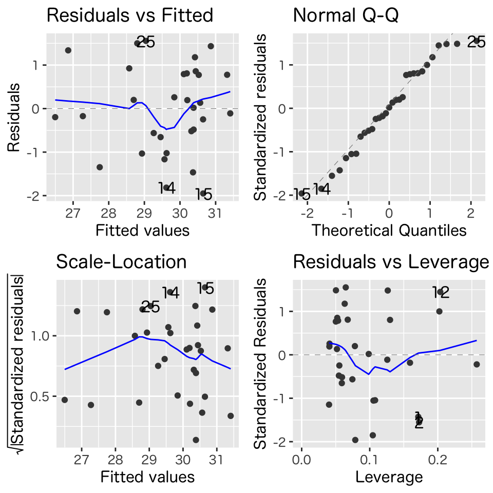

### モデル4の診断プロット

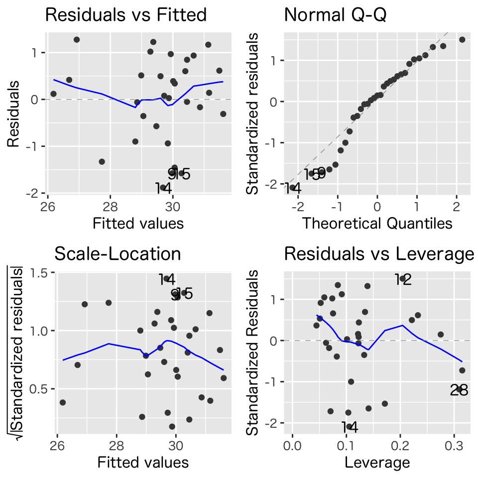

### モデル5の診断プロット

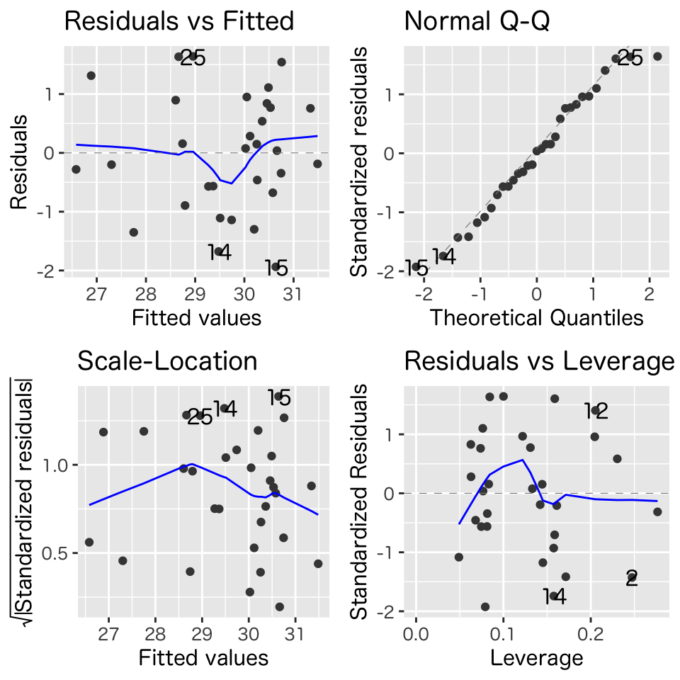

# 回帰モデルによる予測

## 予測

- 新しいデータ (説明変数) $\boldsymbol{x}$ に対する **予測値**
  $$\begin{equation}
  \hat{y}
  =
  (1,\boldsymbol{x}^{\mathsf{T}})\hat{\boldsymbol{\beta}},
  \qquad
  \hat{\boldsymbol{\beta}}
  =
  (X^{\mathsf{T}}X)^{-1}
  X^{\mathsf{T}}\boldsymbol{y}
  \end{equation}$$
- 予測値は元データの目的変数の重み付け線形和
  $$\begin{equation}
  \hat{y}
  =
  \boldsymbol{w}(\boldsymbol{x})^{\mathsf{T}}\boldsymbol{y},
  \qquad
  \boldsymbol{w}(\boldsymbol{x})^{\mathsf{T}}
  =
  (1,\boldsymbol{x}^{\mathsf{T}})
  (X^{\mathsf{T}}X)^{-1}
  X^{\mathsf{T}}
  \end{equation}$$
  - 重みは元データと新規データの説明変数で決定

## 予測値の性質

- 推定量は以下の性質をもつ多変量正規分布
  $$\begin{align}
  \mathbb{E}[\hat{\boldsymbol{\beta}}]
  &=\boldsymbol{\beta}\\
  \mathrm{Cov}(\hat{\boldsymbol{\beta}})
  &=\sigma^{2}(X^{\mathsf{T}}X)^{-1}
  \end{align}$$
- この性質を利用して以下の3つの値の違いを評価
  $$\begin{align}
  y&=(1,\boldsymbol{x}^{\mathsf{T}})\boldsymbol{\beta}+\epsilon
  &&\text{(観測値)}\\
  \tilde{y}&=(1,\boldsymbol{x}^{\mathsf{T}})\boldsymbol{\beta}
  &&\text{(最適な予測値)}\\
  \hat{y}&=(1,\boldsymbol{x}^{\mathsf{T}})\hat{\boldsymbol{\beta}}
  &&\text{(回帰式による予測値)}
  \end{align}$$
  - $\hat{y}$ と $y$ は独立な正規分布に従うことに注意

# 信頼区間

## 最適な予測値との差

- 差の分布は以下の平均・分散をもつ正規分布に従う
  $$\begin{align}
  \mathbb{E}[\tilde{y}-\hat{y}]
  &=(1,\boldsymbol{x}^{\mathsf{T}})\boldsymbol{\beta}
  -(1,\boldsymbol{x}^{\mathsf{T}})\mathbb{E}[\hat{\boldsymbol{\beta}}]
  =0\\
  \mathrm{Var}(\tilde{y}-\hat{y})
  &=\underbrace{\sigma^{2}(1,\boldsymbol{x}^{\mathsf{T}})(X^{\mathsf{T}}X)^{-1}
  (1,\boldsymbol{x}^{\mathsf{T}})^{\mathsf{T}}}_{\text{\(\hat{\boldsymbol{\beta}}\)の推定誤差による分散}}
  =\sigma^{2}\gamma_{c}(\boldsymbol{x})^{2}
  \end{align}$$
- 標準化による表現
  $$\begin{equation}
  \frac{\tilde{y}-\hat{y}}{\sigma\gamma_{c}(\boldsymbol{x})}
  \sim \mathcal{N}(0,1)
  \end{equation}$$

## 信頼区間

- 未知の分散を不偏分散で推定
  $$\begin{equation}
  Z=
  \frac{\tilde{y}-\hat{y}}{\hat{\sigma}\gamma_{c}(\boldsymbol{x})}
  \sim \mathcal{T}(n{-}p{-}1)
  \quad (\text{\(t\)分布})
  \end{equation}$$
- 確率 $\alpha$ の信頼区間
  $$\begin{equation}
  \mathcal{I}^{c}_{\alpha}
  =
  \left[
  \hat{y}-C_{\alpha}\hat{\sigma}\gamma_{c}(\boldsymbol{x}),\;
  \hat{y}+C_{\alpha}\hat{\sigma}\gamma_{c}(\boldsymbol{x})
  \right]
  \end{equation}$$

  $$\begin{equation}
  P(|Z| < {C_{\alpha}} | Z\sim\mathcal{T}(n{-}p{-}1))
  =\alpha
  \end{equation}$$
  - 最適な予測値 $\tilde{y}$ が入ることが期待される区間

# 予測区間

## 観測値との差

- 差の分布は以下の平均・分散をもつ正規分布に従う
  $$\begin{align}
  \mathbb{E}[y-\hat{y}]
  &=(1,\boldsymbol{x}^{\mathsf{T}})\boldsymbol{\beta}
  +\mathbb{E}[\boldsymbol{\epsilon}]
  -(1,\boldsymbol{x}^{\mathsf{T}})
  \mathbb{E}[\hat{\boldsymbol{\beta}}]
  =0\\
  \mathrm{Var}(y-\hat{y})
  &=\underbrace{\sigma^{2}
  (1,\boldsymbol{x}^{\mathsf{T}})(X^{\mathsf{T}}X)^{-1}
  (1,\boldsymbol{x}^{\mathsf{T}})^{\mathsf{T}}
  }_{\text{\(\hat{\boldsymbol{\beta}}\)の推定誤差による分散}}
  +\underbrace{\sigma^{2}}_{\text{誤差の分散}}
  =\sigma^{2}\gamma_{p}(\boldsymbol{x})^{2}
  \end{align}$$
- 標準化による表現
  $$\begin{equation}
  \frac{y-\hat{y}}{\sigma\gamma_{p}(\boldsymbol{x})}
  \sim \mathcal{N}(0,1)
  \end{equation}$$

## 予測区間

- 未知の分散を不偏分散で推定
  $$\begin{equation}
  Z=
  \frac{y-\hat{y}}{\hat{\sigma}\gamma_{p}(\boldsymbol{x})}
  \sim \mathcal{T}(n{-}p{-}1)
  \quad (\text{\(t\)分布})
  \end{equation}$$
- 確率 $\alpha$ の予測区間
  $$\begin{equation}
  \mathcal{I}^{p}_{\alpha}
  =
  \left[
  \hat{y}-C_{\alpha}\hat{\sigma}\gamma_{p}(\boldsymbol{x}),\;
  \hat{y}+C_{\alpha}\hat{\sigma}\gamma_{p}(\boldsymbol{x})
  \right]
  \end{equation}$$

  $$\begin{equation}
  P(|Z| < {C_{\alpha}} | Z\sim\mathcal{T}(n{-}p{-}1))
  =\alpha
  \end{equation}$$
  - 観測値 $y$ が入ることが期待される区間
  - $\gamma_{p}>\gamma_{c}$ なので信頼区間より広くなる

# 実習

# 発展的なモデル

## 非線形性を含むモデル

- 目的変数 $y$
- 説明変数 $x_1,\dotsc,x_p$
- 説明変数の追加で対応可能
  - 交互作用 (交差項) : $x_ix_j$ のような説明変数の積
  - 非線形変換 : $\log(x_k)$ のような関数による変換

## カテゴリカル変数を含むモデル

- 数値ではないデータの例
  - *悪性・良性*
  - *血液型 (A型,B型,AB型,O型)*
- 適切な方法で数値に変換して対応
  - 2値の場合は 1,0 (真，偽) を割り当てる
    - 悪性 : 1
    - 良性 : 0
  - 3値以上の場合は **ダミー変数** を利用する (カテゴリ数-1個)
    - A型 : (1,0,0)
    - B型 : (0,1,0)
    - O型 : (0,0,1)
    - AB型 : (0,0,0)

# 実習

# 次回の予定

- **第1回: 主成分分析の考え方**
- 第2回: 分析の評価と視覚化